# Project

Kachina Aschenberg Øwre & Charlene A Boyle

2026-10-27

1. Analyse a data set of your choice using methods covered in this course.
2. Write and hand in a research paper.

Two typical analysis pipelines could look like this:

Supervised learning: (a) PCA/hierarchal clustering/heatmap to get an initial overview of the data, (b) differential expression analysis to reduce the dimensionality, (c) machine learning to predict outcome, (d) extract some biological insight from the machine learning model. Unsupervised learning: (a) PCA/hierarchal clustering/heatmap to get an initial overview of the data, (b) network analysis and module detection, (c) GO enrichment analysis of modules, (d) pathway analysis of selected pathways. Work in groups of four.

REPORT DEADLINE: Write a short research paper (approximately 1500 words) using RMarkdown: Abstract, Introduction, Methods, Results, Discussion and References.

PRESENTATION: Hold a presentation (10 min) for the teachers highlighting your main findings. This will be organized during the Thursday and Friday scheduled hours the last week of the course.

Data should be FAIR (ACRONYM)

# 1 Abstract

# 2 Introduction

## 2.1 Research question

Are the gene co-expression modules associated with Braak stage in the fusiform gyrus the same as those associated with Alzheimer’s disease diagnosis, and what functions do they have?

# 3 Methods

## 3.2 Data

Gene expression data were obtained from the Gene Expression Omnibus (GEO; accession GSE125583) (Srinivasan et al. 2020). The dataset contains bulk RNA-seq of post-mortem fusiform gyrus tissue from 219 patients with Alzheimer’s disease (AD) and 70 age-matched, neurologically normal controls, sequenced on an Illumina HiSeq 2500. We used the raw count table generated by NCBI (reads aligned to GRCh38.p13; 39,376 genes). Diagnosis, age, sex and Braak stage (I–VI) were extracted from the GEO series matrix. Braak stage was missing for two samples, and age and sex for one sample each.

```r
# Gentellinger: gener i rader og prøver i kolonner
counts <- read.delim(
  "data/GSE125583_raw_counts.tsv.gz",
  row.names = 1,
  check.names = FALSE
)

# Informasjon om hver prøve
traits <- read.csv(
  "data/GSE125583_traits.csv",
  stringsAsFactors = FALSE
)

# kontroll av innlesningene
dim(counts)
```

```
## [1] 39376   289
```

```r
dim(traits)
```

```
## [1] 289   6
```

```r
counts[1:4, 1:4]
```

```
##           GSM3577568 GSM3577569 GSM3577570 GSM3577571
## 100287102         15         34         32         50
## 653635           494        732        557        813
## 102466751          2         13          9          9
## 107985730          2          2          1          2
```

```r
head(traits)
```

```
##       sample case_id diagnosis age sex braak
## 1 GSM3577568   04-45        AD  93   F    IV
## 2 GSM3577569   11-73        AD  77   M    VI
## 3 GSM3577570   10-11        AD  92   M    IV
## 4 GSM3577571   11-20        AD  85   M    IV
## 5 GSM3577572   11-92        AD  83   M    IV
## 6 GSM3577573   08-34        AD  85   M    IV
```

## 3.3 Preprocessing

Genes with at least 10 counts in at least 20% of the samples (58 of 289) were kept, leaving 21,487 genes. Counts were normalized for library size and transformed with the variance-stabilizing transformation (VST) in DESeq2 (Love et al. 2014). The transformed data were explored with principal component analysis (PCA) and hierarchical clustering of samples (Euclidean distance, complete linkage).

```r
# Minste antall prøver: 20 % av alle prøvene, rundet opp
min.samples <- ceiling(0.20 * ncol(counts))

# Behold gener med minst 10 tellinger i minst dette antallet prøver
keep <- rowSums(counts >= 10) >= min.samples
counts.filtered <- counts[keep, , drop = FALSE]

# Kontroller antall prøver som kreves og antall gener som beholdes
min.samples
```

```
## [1] 58
```

```r
nrow(counts.filtered)
```

```
## [1] 21487
```

```r
library(DESeq2)

# Bruk prøve-ID-ene som radnavn i prøveinformasjonen
rownames(traits) <- traits$sample

# Samle gentellinger og prøveinformasjon i et DESeq2-objekt
dds <- DESeqDataSetFromMatrix(
  countData = as.matrix(counts.filtered),
  colData = traits,
  design = ~ 1
)

# Beregn normaliseringsfaktorer for prøvene
dds <- estimateSizeFactors(dds)

# VST-transformer og hent ut uttrykksmatrisen
vst <- varianceStabilizingTransformation(dds, blind = TRUE)
expr <- assay(vst)

dim(expr)
```

```
## [1] 21487   289
```

## 3.4 Co-expression network analysis

A signed co-expression network was built from all 21,487 genes with WGCNA (Langfelder & Horvath 2008). The soft-thresholding power was set to 20, the lowest power giving a scale-free fit (R²) of at least 0.80. Modules were detected with `blockwiseModules` (maximum block size 5,000 genes, minimum module size 40, merge cut height 0.25).

## 3.5 Module–trait association

Each module was summarized by its eigengene, the first principal component of its genes. Eigengenes were correlated with diagnosis (AD = 1, control = 0; Pearson) and Braak stage (coded 1–6; Spearman). Associations with diagnosis were also tested in linear models adjusted for age and sex. To separate pathology from clinical diagnosis, a joint model with diagnosis, Braak stage (as a factor), age and sex was compared with reduced models without Braak stage or without diagnosis using F-tests. P-values were adjusted with the Benjamini–Hochberg method, and FDR < 0.05 was considered significant (Benjamini & Hochberg 1995).

## 3.6 Functional enrichment

Four modules (pink, brown, magenta and green) were selected for functional analysis. Enrichment of Gene Ontology biological processes and KEGG pathways was tested with clusterProfiler (Xu et al. 2024), with all network genes as background. Hub genes were defined as the ten genes with the highest module membership (kME), i.e. the strongest correlation with the module eigengene. Possible upstream regulators were explored with the ChEA 2022 library in Enrichr (Kuleshov et al. 2016).

## 3.7 Differential expression and pathway analysis

Differential expression was tested with DESeq2 in the 287 samples with complete information, using the design `~ age + sex + braak + diagnosis`. AD and controls were compared with a Wald test, and the effect of Braak stage beyond diagnosis was tested with a likelihood-ratio test against the reduced model `~ age + sex + diagnosis`. Genes with adjusted p < 0.05 were considered significant. Log2 fold changes for AD versus control were mapped onto the KEGG glutamatergic synapse pathway (hsa04724) with pathview (Luo & Brouwer 2013).

## 3.8 Software

# 4 Results

## 4.1 Overview

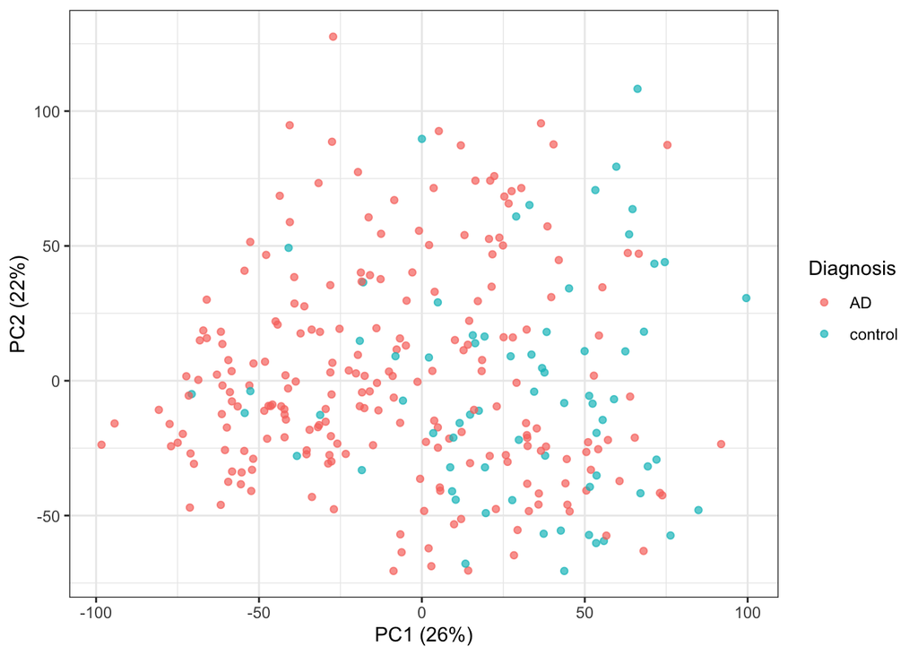

```r
library(ggplot2)

# PCA trenger prøver i rader og gener i kolonner
pca <- prcomp(t(expr), center = TRUE, scale. = FALSE)

# Prosent av variasjonen forklart av hver hovedkomponent
variance <- 100 * pca$sdev^2 / sum(pca$sdev^2)

# Samle koordinater og diagnose
pca.data <- data.frame(
  PC1 = pca$x[, 1],
  PC2 = pca$x[, 2],
  diagnosis = traits$diagnosis
)

# Tegn PCA-plottet
ggplot(pca.data, aes(x = PC1, y = PC2, color = diagnosis)) +
  geom_point(alpha = 0.7) +
  labs(
    x = paste0("PC1 (", round(variance[1], 1), "%)"),
    y = paste0("PC2 (", round(variance[2], 1), "%)"),
    color = "Diagnosis"
  ) +
  theme_bw()
```

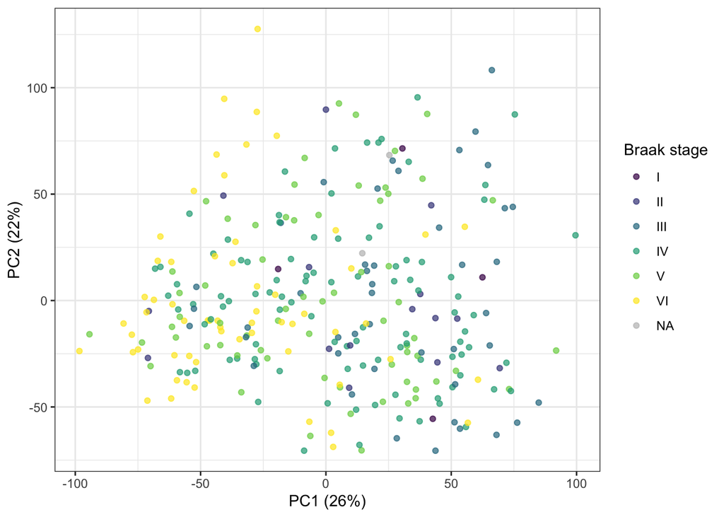

```r
# Legg til Braak-stadium i riktig rekkefølge
pca.data$braak <- factor(
  traits$braak,
  levels = c("I", "II", "III", "IV", "V", "VI")
)

# Samme PCA, farget etter Braak-stadium
ggplot(pca.data, aes(x = PC1, y = PC2, color = braak)) +
  geom_point(alpha = 0.7) +
  scale_color_viridis_d(na.value = "grey") +
  labs(
    x = paste0("PC1 (", round(variance[1], 1), "%)"),
    y = paste0("PC2 (", round(variance[2], 1), "%)"),
    color = "Braak stage"
  ) +
  theme_bw()
```

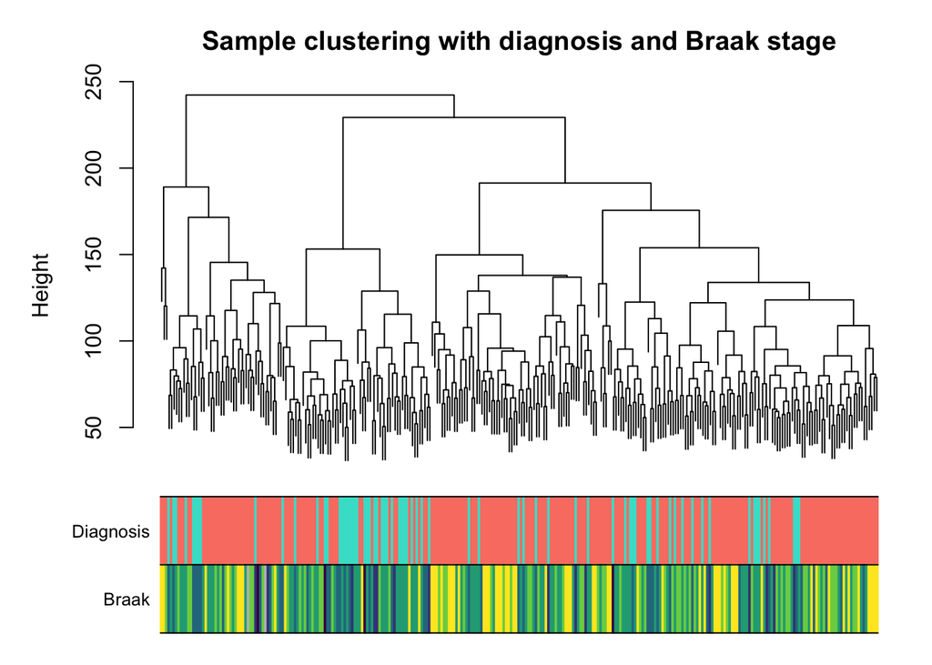

```r
library(WGCNA)

# Beregn avstand mellom prøvene og lag treet
sample.dist <- dist(t(expr), method = "euclidean")
sample.tree <- hclust(sample.dist, method = "complete")

# Farger for diagnose: AD = laksefarget, kontroll = turkis
diagnosis.colors <- ifelse(
  traits$diagnosis == "AD",
  "salmon",
  "turquoise"
)
diagnosis.colors[is.na(traits$diagnosis)] <- "grey"

# Farger for Braak-stadium I–VI
braak.palette <- c(
  I = "#440154",
  II = "#414487",
  III = "#2A788E",
  IV = "#22A884",
  V = "#7AD151",
  VI = "#FDE725"
)

braak.colors <- unname(
  braak.palette[as.character(traits$braak)]
)
braak.colors[is.na(braak.colors)] <- "grey"

# Samle fargestripene
trait.colors <- cbind(
  Diagnosis = diagnosis.colors,
  Braak = braak.colors
)

# Tegn treet med fargestriper
plotDendroAndColors(
  sample.tree,
  colors = trait.colors,
  groupLabels = c("Diagnosis", "Braak"),
  dendroLabels = FALSE,
  main = "Sample clustering with diagnosis and Braak stage"
)
```

## 4.2 Co-expression modules

```r
# Snu matrisen: prøver i rader, gener i kolonner
datExpr <- t(expr)

# Kontroller manglende verdier og gener uten variasjon
gsg <- WGCNA::goodSamplesGenes(datExpr, verbose = 3)
```

```
##  Flagging genes and samples with too many missing values...
##   ..step 1
```

```r
# Vis om alle prøver og gener bestod kontrollen
gsg$allOK
```

```
## [1] TRUE
```

```r
# Vis antall prøver og gener
dim(datExpr)
```

```
## [1]   289 21487
```

```r
# Test flere power-verdier
powers <- c(1:10, seq(12, 30, by = 2))

sft <- WGCNA::pickSoftThreshold(
  datExpr,
  powerVector = powers,
  networkType = "signed",
  RsquaredCut = 0.80,
  blockSize = 1000,
  verbose = 5
)
```

```
##  pickSoftThreshold: calculating connectivity for given powers...
##    ..working on genes 1 through 1000 of 21487
```

```
##    ..working on genes 1001 through 2000 of 21487
##    ..working on genes 2001 through 3000 of 21487
##    ..working on genes 3001 through 4000 of 21487
##    ..working on genes 4001 through 5000 of 21487
##    ..working on genes 5001 through 6000 of 21487
##    ..working on genes 6001 through 7000 of 21487
##    ..working on genes 7001 through 8000 of 21487
##    ..working on genes 8001 through 9000 of 21487
##    ..working on genes 9001 through 10000 of 21487
##    ..working on genes 10001 through 11000 of 21487
##    ..working on genes 11001 through 12000 of 21487
##    ..working on genes 12001 through 13000 of 21487
##    ..working on genes 13001 through 14000 of 21487
##    ..working on genes 14001 through 15000 of 21487
##    ..working on genes 15001 through 16000 of 21487
##    ..working on genes 16001 through 17000 of 21487
##    ..working on genes 17001 through 18000 of 21487
##    ..working on genes 18001 through 19000 of 21487
##    ..working on genes 19001 through 20000 of 21487
##    ..working on genes 20001 through 21000 of 21487
##    ..working on genes 21001 through 21487 of 21487
##    Power SFT.R.sq slope truncated.R.sq mean.k. median.k. max.k.
## 1      1    0.055  6.96          0.792 10800.0  10800.00  11100
## 2      2    0.171 -5.29          0.875  5980.0   5950.00   6880
## 3      3    0.183 -2.37          0.873  3590.0   3570.00   4770
## 4      4    0.187 -1.46          0.810  2300.0   2270.00   3520
## 5      5    0.230 -1.19          0.765  1540.0   1500.00   2720
## 6      6    0.296 -1.08          0.751  1080.0   1030.00   2160
## 7      7    0.394 -1.03          0.782   777.0    724.00   1760
## 8      8    0.504 -1.02          0.827   577.0    519.00   1460
## 9      9    0.611 -1.02          0.879   439.0    379.00   1230
## 10    10    0.671 -1.09          0.896   340.0    281.00   1070
## 11    12    0.717 -1.26          0.901   216.0    160.00    835
## 12    14    0.754 -1.37          0.920   144.0     94.80    674
## 13    16    0.761 -1.48          0.920   100.0     58.00    556
## 14    18    0.774 -1.54          0.927    72.3     36.50    467
## 15    20    0.801 -1.57          0.946    53.5     23.40    397
## 16    22    0.808 -1.60          0.951    40.5     15.40    342
## 17    24    0.822 -1.62          0.958    31.3     10.30    297
## 18    26    0.825 -1.64          0.960    24.5      7.01    260
## 19    28    0.841 -1.64          0.969    19.5      4.78    229
## 20    30    0.849 -1.64          0.973    15.7      3.34    203
```

```r
# Vis foreslått power og resultatene
sft$powerEstimate
```

```
## [1] 20
```

```r
sft$fitIndices
```

```
##    Power   SFT.R.sq     slope truncated.R.sq     mean.k.    median.k.
## 1      1 0.05496062  6.964821      0.7919864 10763.35145 10773.751281
## 2      2 0.17133489 -5.294846      0.8754384  5981.41187  5952.012631
## 3      3 0.18268025 -2.372190      0.8730234  3594.28413  3570.708934
## 4      4 0.18653084 -1.459604      0.8103034  2295.94593  2268.031741
## 5      5 0.22995166 -1.190461      0.7653247  1540.37107  1504.160951
## 6      6 0.29566240 -1.078154      0.7512732  1075.81698  1030.501553
## 7      7 0.39372139 -1.031172      0.7815761   776.85576   723.956765
## 8      8 0.50380716 -1.017824      0.8274424   576.91098   518.982078
## 9      9 0.61055870 -1.023391      0.8790255   438.72401   379.399715
## 10    10 0.67102411 -1.089066      0.8959336   340.48149   280.992801
## 11    12 0.71685805 -1.260735      0.9010017   215.62776   159.710052
## 12    14 0.75407198 -1.373392      0.9200426   144.06498    94.771358
## 13    16 0.76103320 -1.476609      0.9197175   100.35588    58.044994
## 14    18 0.77368893 -1.544892      0.9273675    72.28028    36.489507
```

[output cut: 27 more lines]

```r
softPower <- 20
```

```r
# Gjør analysen mer reproduserbar
set.seed(3)

# Finn genmoduler
modules <- WGCNA::blockwiseModules(
  datExpr,
  power = softPower,
  networkType = "signed",
  TOMType = "signed",
  minModuleSize = 40,
  mergeCutHeight = 0.25,
  maxBlockSize = 5000,
  numericLabels = FALSE,
  randomSeed = 3,
  verbose = 3
)

# Antall gener i hver modul
table(modules$colors)

# Hent modulenes oppsummerte uttrykksprofiler
MEs <- modules$MEs
```

```r
table(modules$colors)
```

```
##
##        black         blue        brown         cyan    darkgreen      darkred
##          877         2750         2588          160           95          103
##        green  greenyellow         grey       grey60    lightcyan   lightgreen
##         1256          440         3240          147          148          138
##  lightyellow      magenta midnightblue         pink       purple          red
##          138          723          156          766          522         1231
##    royalblue       salmon          tan    turquoise       yellow
##          124          247          440         2944         2254
```

## 4.3 Module–trait relationships

```r
# Diagnose: kontroll = 0, AD = 1
traits$AD <- ifelse(traits$diagnosis == "AD", 1, 0)

# Gjør Braak I–VI om til tallene 1–6
traits$braak.numeric <- match(
  traits$braak,
  c("I", "II", "III", "IV", "V", "VI")
)

# Kontroller omkodingen
table(traits$diagnosis, traits$AD, useNA = "ifany")
```

```
##
##             0   1
##   AD        0 219
##   control  70   0
```

```r
table(traits$braak, traits$braak.numeric, useNA = "ifany")
```

```
##
##         1  2  3  4  5  6 <NA>
##   I     4  0  0  0  0  0    0
##   II    0 15  0  0  0  0    0
##   III   0  0 44  0  0  0    0
##   IV    0  0  0 99  0  0    0
##   V     0  0  0  0 65  0    0
##   VI    0  0  0  0  0 60    0
##   <NA>  0  0  0  0  0  0    2
```

```r
# Utelat grey, som inneholder gener uten modultilhørighet
MEs <- modules$MEs
MEs <- MEs[, colnames(MEs) != "MEgrey", drop = FALSE]

# Sett prøveinformasjonen i samme rekkefølge som eigengenene
trait.data <- traits[
  match(rownames(MEs), traits$sample),
]

stopifnot(identical(rownames(MEs), trait.data$sample))

# Test sammenheng med diagnose og Braak for hver modul
module.results <- do.call(
  rbind,
  lapply(colnames(MEs), function(module) {

    diagnosis.test <- cor.test(
      MEs[[module]], trait.data$AD,
      method = "pearson"
    )

    braak.test <- cor.test(
      MEs[[module]], trait.data$braak.numeric,
      method = "spearman",
      exact = FALSE
    )

    data.frame(
      Module = sub("^ME", "", module),
      Diagnosis_r = unname(diagnosis.test$estimate),
      Diagnosis_p = diagnosis.test$p.value,
      Braak_rho = unname(braak.test$estimate),
      Braak_p = braak.test$p.value
    )
  })
)

# Korriger for at vi tester mange moduler
module.results$Diagnosis_FDR <- p.adjust(
  module.results$Diagnosis_p, method = "BH"
)

module.results$Braak_FDR <- p.adjust(
  module.results$Braak_p, method = "BH"
)

# Vis resultatene
module.results
```

```
##          Module Diagnosis_r  Diagnosis_p   Braak_rho      Braak_p Diagnosis_FDR
## 1     darkgreen -0.15243229 9.450781e-03 -0.15292479 9.467818e-03  1.732643e-02
## 2         brown -0.29958722 2.095979e-07 -0.35246277 8.082077e-10  6.270465e-07
## 3        salmon -0.37745344 3.223561e-11 -0.25969457 8.311158e-06  2.363944e-10
## 4          cyan -0.31635761 3.872170e-08 -0.29912566 2.415806e-07  1.419795e-07
## 5       darkred -0.29872260 2.280169e-07 -0.39438452 4.054496e-12  6.270465e-07
## 6     turquoise -0.35180805 7.621393e-10 -0.32365855 2.012280e-08  4.191766e-09
## 7   lightyellow  0.06031078 3.068897e-01 -0.03338039 5.733064e-01  3.971514e-01
## 8    lightgreen  0.26770605 3.915807e-06  0.14453808 1.425284e-02  9.571973e-06
## 9       magenta  0.18213564 1.877651e-03  0.14169953 1.629683e-02  3.755301e-03
## 10        black  0.41502757 1.846252e-13  0.37055661 9.023793e-11  4.061755e-12
## 11        green  0.39145431 5.080005e-12  0.34851727 1.280257e-09  5.588005e-11
## 12  greenyellow  0.01997815 7.352197e-01  0.08640767 1.442399e-01  7.352197e-01
## 13    lightcyan -0.03539607 5.489641e-01 -0.07671734 1.950055e-01  6.356426e-01
## 14       yellow  0.02395234 6.851224e-01 -0.04296097 4.684745e-01  7.304031e-01
```

[output cut: 31 more lines]

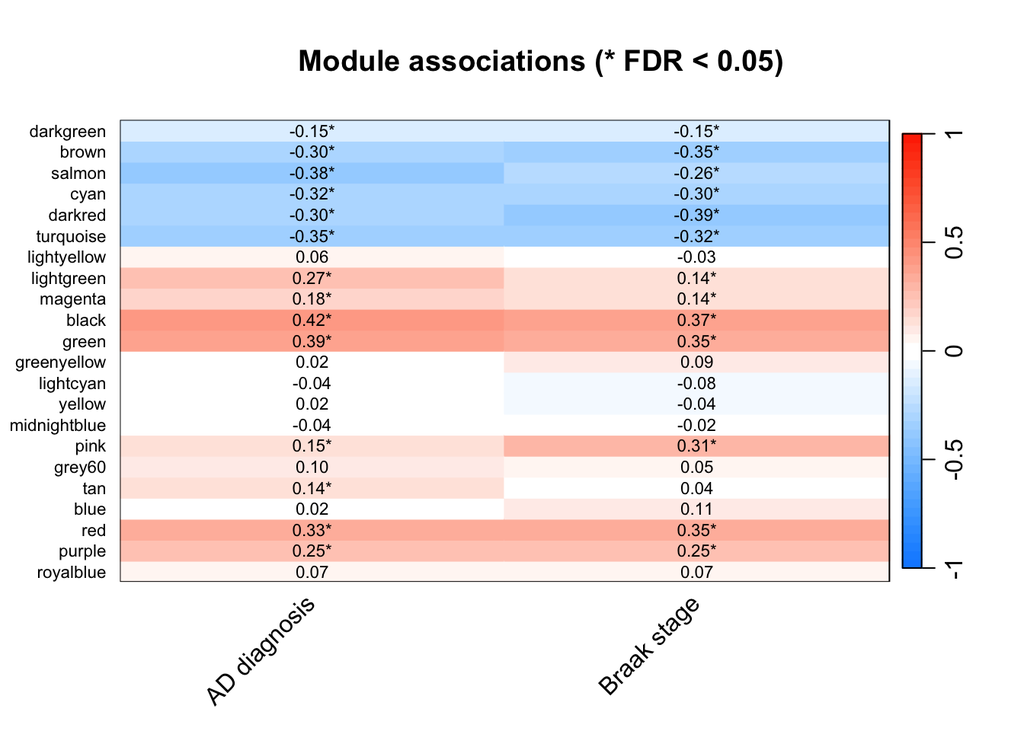

```r
# Samle korrelasjonene i en matrise
cor.matrix <- as.matrix(
  module.results[, c("Diagnosis_r", "Braak_rho")]
)

rownames(cor.matrix) <- module.results$Module
colnames(cor.matrix) <- c("AD diagnosis", "Braak stage")

# Samle korrigerte p-verdier
fdr.matrix <- as.matrix(
  module.results[, c("Diagnosis_FDR", "Braak_FDR")]
)

# Vis korrelasjon og marker FDR < 0.05 med stjerne
plot.labels <- matrix(
  paste0(
    sprintf("%.2f", cor.matrix),
    ifelse(fdr.matrix < 0.05, "*", "")
  ),
  nrow = nrow(cor.matrix),
  ncol = ncol(cor.matrix)
)

# Tegn heatmap
WGCNA::labeledHeatmap(
  Matrix = cor.matrix,
  xLabels = colnames(cor.matrix),
  yLabels = rownames(cor.matrix),
  ySymbols = rownames(cor.matrix),
  colorLabels = FALSE,
  colors = WGCNA::blueWhiteRed(50),
  textMatrix = plot.labels,
  setStdMargins = FALSE,
  plotLegend = TRUE,
  zlim = c(-1, 1),
  cex.text = 0.7,
  main = "Module associations (* FDR < 0.05)",
  cex.lab.y = 0.7,
  margins = c(7, 10)
)
```

```r
# Klargjør alder og kjønn
trait.data$age <- as.numeric(trait.data$age)
trait.data$sex <- factor(trait.data$sex)

# Undersøk hver modul, justert for alder og kjønn
adjusted.results <- do.call(
  rbind,
  lapply(colnames(MEs), function(module) {

    model.data <- data.frame(
      ME = MEs[[module]],
      AD = trait.data$AD,
      age = trait.data$age,
      sex = trait.data$sex
    )

    model <- lm(ME ~ AD + age + sex, data = model.data)
    result <- coef(summary(model))

    data.frame(
      Module = sub("^ME", "", module),
      AD_difference = result["AD", "Estimate"],
      AD_p = result["AD", "Pr(>|t|)"],
      Samples = nobs(model)
    )
  })
)

# Korriger for testing av mange moduler
adjusted.results$AD_FDR <- p.adjust(
  adjusted.results$AD_p,
  method = "BH"
)

# Vis de minste korrigerte p-verdiene først
adjusted.results <- adjusted.results[
  order(adjusted.results$AD_FDR),
]

adjusted.results
```

```
##          Module AD_difference         AD_p Samples       AD_FDR
## 10        black   0.055638096 1.215690e-12     288 2.674518e-11
## 11        green   0.050616656 8.325441e-11     288 9.157985e-10
## 3        salmon  -0.046644562 1.561682e-09     288 1.059042e-08
## 6     turquoise  -0.047887140 1.925532e-09     288 1.059042e-08
## 4          cyan  -0.043567016 6.399725e-08     288 2.423709e-07
## 20          red   0.042375242 6.610115e-08     288 2.423709e-07
## 2         brown  -0.038809799 8.628786e-07     288 2.711904e-06
## 5       darkred  -0.037446833 1.792890e-06     288 4.930448e-06
## 8    lightgreen   0.036980753 4.635498e-06     288 1.133122e-05
## 21       purple   0.033389663 3.789043e-05     288 8.335894e-05
## 9       magenta   0.026315365 1.375644e-03     288 2.751289e-03
## 1     darkgreen  -0.021860465 8.132765e-03     288 1.491007e-02
## 18          tan   0.020949078 1.130772e-02     288 1.913614e-02
## 16         pink   0.016955205 3.529838e-02     288 5.546888e-02
## 7   lightyellow   0.013716903 9.018969e-02     288 1.322782e-01
## 17       grey60   0.008352083 3.012917e-01     288 4.142761e-01
## 22    royalblue   0.007950307 3.345434e-01     288 4.329385e-01
## 13    lightcyan  -0.005819122 4.836656e-01     288 5.911468e-01
## 12  greenyellow   0.005421144 5.126411e-01     288 5.935844e-01
## 14       yellow   0.004479293 5.875284e-01     288 6.155060e-01
## 15 midnightblue  -0.004571323 5.807040e-01     288 6.155060e-01
## 19         blue   0.001322658 8.723873e-01     288 8.723873e-01
```

```r
# Sett Braak-stadiene i riktig rekkefølge
braak.stage <- factor(
  traits$braak,
  levels = c("I", "II", "III", "IV", "V", "VI")
)

# Tell prøver per diagnose og Braak-stadium
table(
  Diagnosis = traits$diagnosis,
  Braak = braak.stage,
  useNA = "ifany"
)
```

```
##          Braak
## Diagnosis  I II III IV  V VI <NA>
##   AD       1  5  18 68 65 60    2
##   control  3 10  26 31  0  0    0
```

```r
# Braak behandles som seks kategorier
trait.data$braak.factor <- factor(
  trait.data$braak,
  levels = c("I", "II", "III", "IV", "V", "VI")
)

joint.results <- do.call(
  rbind,
  lapply(colnames(MEs), function(module) {

    model.data <- data.frame(
      ME = MEs[[module]],
      AD = trait.data$AD,
      braak = trait.data$braak.factor,
      age = trait.data$age,
      sex = trait.data$sex
    )

    # Bruk de samme prøvene i alle modellene
    model.data <- model.data[complete.cases(model.data), ]

    full.model <- lm(
      ME ~ AD + braak + age + sex,
      data = model.data
    )

    # Test diagnose utover Braak, alder og kjønn
    without.AD <- update(full.model, . ~ . - AD)

    # Test Braak samlet utover diagnose, alder og kjønn
    without.braak <- update(full.model, . ~ . - braak)

    data.frame(
      Module = sub("^ME", "", module),
      Diagnosis_p = anova(without.AD, full.model)[2, "Pr(>F)"],
      Braak_p = anova(without.braak, full.model)[2, "Pr(>F)"],
      Samples = nobs(full.model)
    )
  })
)

# Korriger for testing av mange moduler
joint.results$Diagnosis_FDR <- p.adjust(
  joint.results$Diagnosis_p, method = "BH"
)

joint.results$Braak_FDR <- p.adjust(
  joint.results$Braak_p, method = "BH"
)

joint.results
```

```
##          Module  Diagnosis_p      Braak_p Samples Diagnosis_FDR    Braak_FDR
## 1     darkgreen 2.319879e-01 3.855768e-01     287  3.402489e-01 5.301682e-01
## 2         brown 4.029753e-03 2.377137e-03     287  1.108182e-02 1.307425e-02
## 3        salmon 1.180493e-07 2.064876e-01     287  1.653125e-06 3.626698e-01
## 4          cyan 2.488415e-04 9.654094e-02     287  9.124187e-04 1.930819e-01
## 5       darkred 1.916024e-02 2.036657e-06     287  3.832048e-02 4.480644e-05
## 6     turquoise 2.023975e-05 1.694628e-02     287  1.113186e-04 4.660226e-02
## 7   lightyellow 6.256132e-02 8.917448e-03     287  1.058730e-01 3.269731e-02
## 8    lightgreen 4.008522e-05 7.550563e-01     287  1.763750e-04 8.142945e-01
## 9       magenta 2.640682e-02 3.343771e-01     287  4.841250e-02 4.904197e-01
## 10        black 1.502841e-07 1.256171e-03     287  1.653125e-06 1.096689e-02
## 11        green 5.608324e-07 7.782576e-03     287  4.112771e-06 3.269731e-02
## 12  greenyellow 6.634219e-01 2.585750e-01     287  7.681727e-01 4.063321e-01
## 13    lightcyan 8.431762e-01 5.502117e-01     287  9.274939e-01 6.370873e-01
## 14       yellow 3.359526e-01 8.771400e-01     287  4.564620e-01 8.771400e-01
## 15 midnightblue 3.527206e-01 4.313745e-01     287  4.564620e-01 5.582494e-01
## 16         pink 9.944705e-01 1.495485e-03     287  9.944705e-01 1.096689e-02
## 17       grey60 1.502955e-01 5.481398e-01     287  2.361786e-01 6.370873e-01
## 18          tan 1.905649e-02 7.405732e-02     287  3.832048e-02 1.629261e-01
## 19         blue 5.638279e-01 7.772811e-01     287  6.891230e-01 8.142945e-01
## 20          red 5.622867e-04 1.378049e-02     287  1.767187e-03 4.331012e-02
## 21       purple 1.144182e-02 4.665069e-02     287  2.796889e-02 1.140350e-01
## 22    royalblue 9.544343e-01 2.143049e-01     287  9.944705e-01 3.626698e-01
```

## 4.4 Functional enrichment

```r
# Kontroller at hvert gen har en modulmerking
stopifnot(length(modules$colors) == ncol(datExpr))

# Modulene vi vil undersøke videre
selected.modules <- c("pink", "brown", "magenta", "green")

# Hent gen-ID-ene fra hver modul
module.genes <- setNames(
  lapply(selected.modules, function(module) {
    colnames(datExpr)[modules$colors == module]
  }),
  selected.modules
)

# Antall gener i hver liste
lengths(module.genes)
```

```
##    pink   brown magenta   green
##     766    2588     723    1256
```

```r
# Alle gener som inngikk i WGCNA, til bakgrunn for GO-analysen
background.genes <- colnames(datExpr)
```

```r
library(clusterProfiler)
library(org.Hs.eg.db)

# GO-analyse av biologiske prosesser i pink-modulen
go.pink <- enrichGO(
  gene = module.genes$pink,
  universe = background.genes,
  OrgDb = org.Hs.eg.db,
  keyType = "ENTREZID",
  ont = "BP",
  pAdjustMethod = "BH",
  pvalueCutoff = 0.05,
  qvalueCutoff = 0.05,
  readable = TRUE
)

# Vis de første resultatene
head(as.data.frame(go.pink)[, c(
  "Description", "GeneRatio", "p.adjust", "Count"
)])
```

```
##                                            Description GeneRatio     p.adjust
## GO:0007272                     ensheathment of neurons    22/466 1.184639e-06
## GO:0008366                           axon ensheathment    22/466 1.184639e-06
## GO:0042552                                 myelination    21/466 3.551294e-06
## GO:0048709             oligodendrocyte differentiation    15/466 5.032819e-04
## GO:0022010          central nervous system myelination     8/466 5.032819e-04
## GO:0032291 axon ensheathment in central nervous system     8/466 5.032819e-04
##            Count
## GO:0007272    22
## GO:0008366    22
## GO:0042552    21
## GO:0048709    15
## GO:0022010     8
## GO:0032291     8
```

```r
# Samme analyse for de tre neste modulene
other.modules <- c("brown", "magenta", "green")

go.other <- setNames(
  lapply(other.modules, function(module) {
    enrichGO(
      gene = module.genes[[module]],
      universe = background.genes,
      OrgDb = org.Hs.eg.db,
      keyType = "ENTREZID",
      ont = "BP",
      pAdjustMethod = "BH",
      pvalueCutoff = 0.05,
      qvalueCutoff = 0.05,
      readable = TRUE
    )
  }),
  other.modules
)

# Vis de seks første resultatene for hver modul
for (module in other.modules) {
  cat("\nModul:", module, "\n")

  results <- as.data.frame(go.other[[module]])

  print(head(results[, c(
    "Description", "GeneRatio", "p.adjust", "Count"
  )]))
}
```

```
##
## Modul: brown
##                                                     Description GeneRatio
## GO:0050804         modulation of chemical synaptic transmission  117/1842
## GO:0099177               regulation of trans-synaptic signaling  117/1842
## GO:0099003                vesicle-mediated transport in synapse   70/1842
## GO:0034765 regulation of monoatomic ion transmembrane transport  106/1842
## GO:0099504                               synaptic vesicle cycle   63/1842
## GO:0048167                    regulation of synaptic plasticity   61/1842
##                p.adjust Count
## GO:0050804 3.165553e-12   117
## GO:0099177 3.165553e-12   117
## GO:0099003 4.342670e-12    70
## GO:0034765 4.342670e-12   106
## GO:0099504 6.028168e-11    63
## GO:0048167 1.056470e-09    61
##
## Modul: magenta
##                                     Description GeneRatio     p.adjust Count
## GO:0002181              cytoplasmic translation    81/537 2.088761e-73    81
## GO:0042274   ribosomal small subunit biogenesis    29/537 5.402564e-15    29
## GO:0042254                  ribosome biogenesis    46/537 1.085968e-12    46
## GO:0022613 ribonucleoprotein complex biogenesis    53/537 1.123538e-10    53
## GO:0042255                    ribosome assembly    18/537 2.027320e-09    18
## GO:0000028     ribosomal small subunit assembly    10/537 1.557300e-07    10
##
## Modul: green
##                      Description GeneRatio   p.adjust Count
## GO:0042026     protein refolding     9/860 0.04516458     9
## GO:0016575 histone deacetylation     8/860 0.04516458     8
```

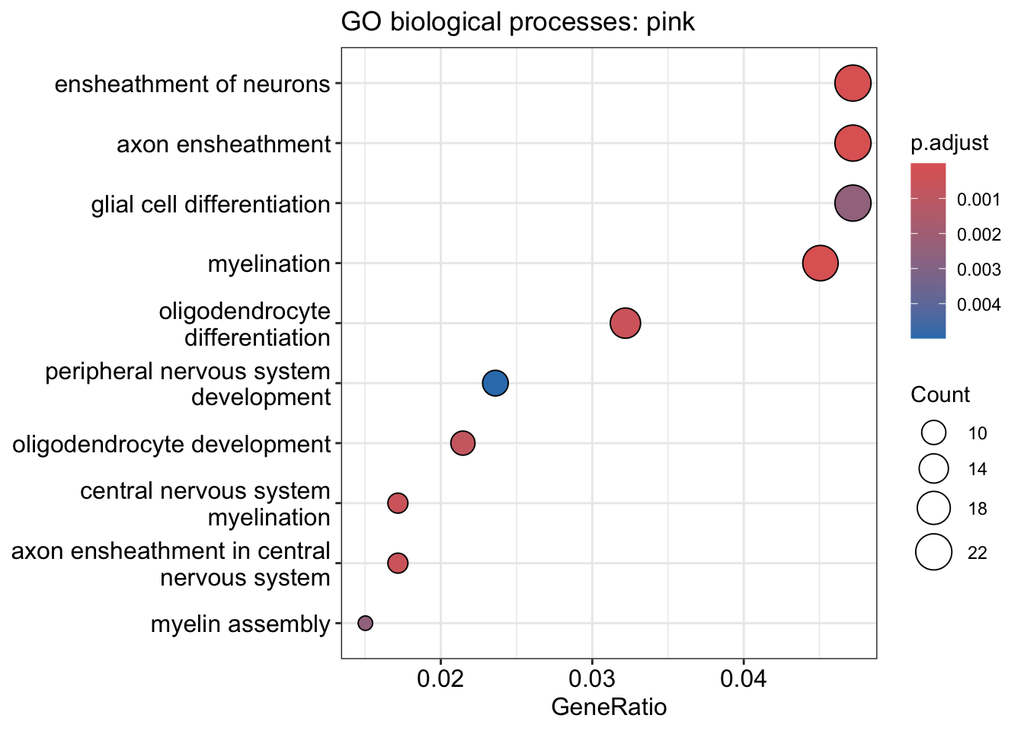

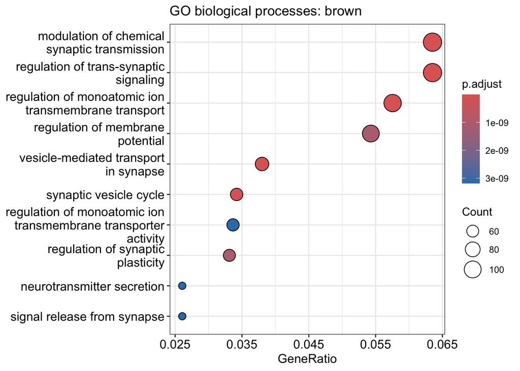

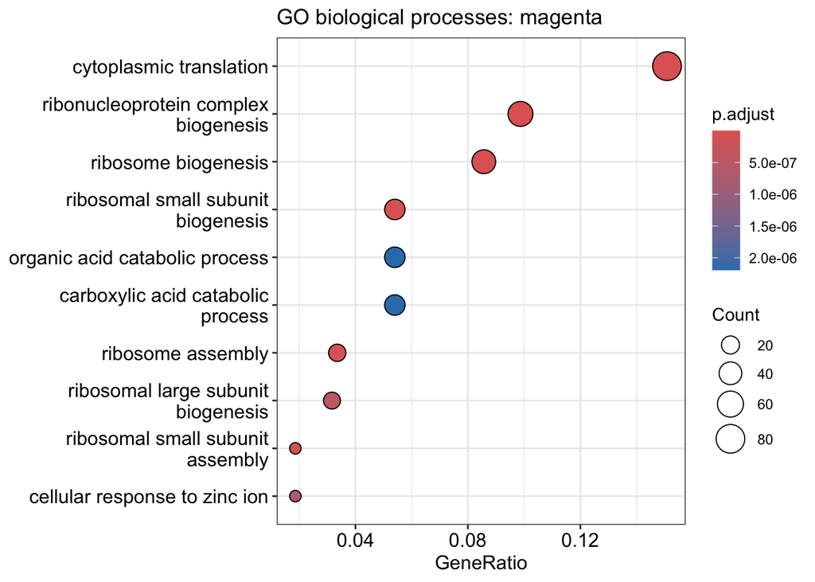

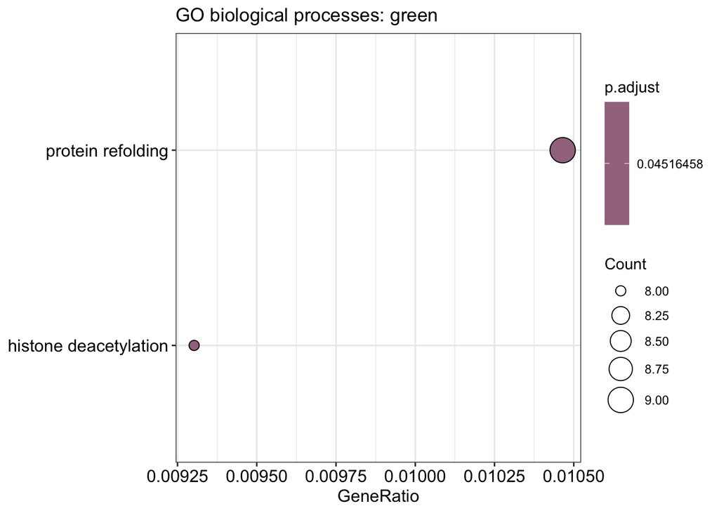

```r
# Samle resultatene fra alle fire modulene
go.all <- c(list(pink = go.pink), go.other)

# Lag én figur per modul
for (module in names(go.all)) {
  if (nrow(as.data.frame(go.all[[module]])) > 0) {
    print(
      enrichplot::dotplot(
        go.all[[module]],
        showCategory = 10
      ) +
        ggplot2::ggtitle(paste("GO biological processes:", module))
    )
  }
}
```

```r
# KEGG-analyse for hver av de fire modulene
kegg.results <- setNames(
  lapply(names(module.genes), function(module) {
    clusterProfiler::enrichKEGG(
      gene = module.genes[[module]],
      universe = background.genes,
      organism = "hsa",
      keyType = "ncbi-geneid",
      pAdjustMethod = "BH",
      pvalueCutoff = 0.05,
      qvalueCutoff = 0.05
    )
  }),
  names(module.genes)
)

# Vis de første resultatene for hver modul
for (module in names(kegg.results)) {
  cat("\nModul:", module, "\n")

  results <- as.data.frame(kegg.results[[module]])

  print(head(results[, c(
    "ID", "Description", "GeneRatio", "p.adjust", "Count"
  )]))
}
```

```
##
## Modul: pink
##                ID          Description GeneRatio  p.adjust Count
## hsa00340 hsa00340 Histidine metabolism     5/222 0.0418231     5
##
## Modul: brown
##                ID                             Description GeneRatio
## hsa05016 hsa05016                      Huntington disease    73/863
## hsa05012 hsa05012                       Parkinson disease    65/863
## hsa04082 hsa04082            Neuroactive ligand signaling    50/863
## hsa04721 hsa04721                  Synaptic vesicle cycle    28/863
## hsa04080 hsa04080 Neuroactive ligand-receptor interaction    64/863
## hsa00190 hsa00190               Oxidative phosphorylation    39/863
##              p.adjust Count
## hsa05016 1.406279e-07    73
## hsa05012 1.586054e-07    65
## hsa04082 1.586054e-07    50
## hsa04721 2.247784e-07    28
## hsa04080 4.565158e-07    64
## hsa00190 7.520572e-07    39
##
## Modul: magenta
##                ID            Description GeneRatio     p.adjust Count
## hsa03010 hsa03010               Ribosome    83/326 2.218035e-60    83
## hsa05171 hsa05171    Coronavirus disease    83/326 1.080967e-58    83
## hsa04978 hsa04978     Mineral absorption    10/326 8.671047e-03    10
## hsa00071 hsa00071 Fatty acid degradation     8/326 2.512160e-02     8
##
## Modul: green
## [1] ID          Description GeneRatio   p.adjust    Count
## <0 rows> (or 0-length row.names)
```

```r
library(enrichR)

# Hent oversikten over tilgjengelige databaser
enrichr.databases <- enrichR::listEnrichrDbs()

# Vis databaser med ChEA i navnet
enrichr.databases[
  grepl("ChEA", enrichr.databases$libraryName),
  "libraryName",
  drop = FALSE
]
```

```
##                                   libraryName
## 4                                   ChEA_2013
## 63                                  ChEA_2015
## 83  ENCODE_and_ChEA_Consensus_TFs_from_ChIP-X
## 91                                  ChEA_2016
## 165                                 ChEA_2022
```

```r
# Koble Entrez-ID-er til vanlige gennavn
gene.symbols <- AnnotationDbi::mapIds(
  org.Hs.eg.db,
  keys = as.character(background.genes),
  column = "SYMBOL",
  keytype = "ENTREZID",
  multiVals = "first"
)

# Bakgrunn: alle kartlagte gener fra WGCNA
background.symbols <- unique(
  na.omit(unname(gene.symbols))
)

# Gennavn for hver modul
module.symbols <- lapply(module.genes, function(genes) {
  unique(na.omit(
    unname(gene.symbols[as.character(genes)])
  ))
})

# Kjør regulatoranalysen separat for hver modul
regulator.results <- lapply(
  module.symbols,
  function(genes) {
    enrichR::enrichr(
      genes = genes,
      databases = "ChEA_2022",
      background = background.symbols
    )[["ChEA_2022"]]
  }
)
```

[output not shown]

```r
# Vis opptil fem signifikante treff per modul
for (module in names(regulator.results)) {
  cat("\nModul:", module, "\n")

  result <- regulator.results[[module]]
  result <- result[
    !is.na(result$Adjusted.P.value) &
      result$Adjusted.P.value < 0.05,
    ,
    drop = FALSE
  ]

  result <- result[order(result$Adjusted.P.value), ]

  print(head(
    result[, c("Term", "Adjusted.P.value")],
    5
  ))
}
```

```
##
## Modul: pink
## [1] Term             Adjusted.P.value
## <0 rows> (or 0-length row.names)
##
## Modul: brown
##                                           Term Adjusted.P.value
## 1          SUZ12 20075857 ChIP-Seq MESCs Mouse     3.921751e-28
## 2           REST 21632747 ChIP-Seq MESCs Mouse     3.213680e-22
## 3 EGR1 20690147 ChIP-Seq ERYTHROLEUKEMIA Human     3.810025e-22
## 4          REST 18959480 ChIP-ChIP MESCs Mouse     3.810025e-22
## 5          RCOR3 21632747 ChIP-Seq MESCs Mouse     2.379794e-20
##
## Modul: magenta
##                                                       Term Adjusted.P.value
## 1                       MYC 19079543 ChIP-ChIP MESCs Mouse     1.089946e-28
## 2                        MYC 18555785 ChIP-Seq MESCs Mouse     9.277212e-15
## 3 MYC 28411283 ChIP-Seq MDA231-LM2-4175 Human BreastCancer     2.976572e-12
## 4                        XRN2 22483619 ChIP-Seq HELA Human     3.794587e-12
## 5                       MYC 18358816 ChIP-ChIP MESCs Mouse     6.023500e-12
##
## Modul: green
##                                                Term Adjusted.P.value
## 1      EGR1 20690147 ChIP-Seq ERYTHROLEUKEMIA Human     2.330952e-11
## 2                ELK3 25401928 ChIP-Seq HUVEC Human     2.088851e-10
## 3                NCOR1 26117541 ChIP-Seq K562 Human     1.468253e-06
## 4 CTCF 33576154 ChIP-Seq Human Liver ProstateCancer     1.498518e-06
## 5       TCF21 26020271 ChIP-Seq SMOOTH MUSCLE Human     2.687935e-06
```

## 4.5 Differential expression

```r
# Lag en egen kopi av prøveinformasjonen
de.traits <- traits

# Klargjør variablene
de.traits$diagnosis <- factor(
  de.traits$diagnosis,
  levels = c("control", "AD")
)

de.traits$braak <- factor(
  de.traits$braak,
  levels = c("I", "II", "III", "IV", "V", "VI")
)

de.traits$age <- as.numeric(de.traits$age)
de.traits$sex <- factor(de.traits$sex)

# Behold prøver med informasjon om alle fire variablene
keep.samples <- complete.cases(
  de.traits[, c("diagnosis", "braak", "age", "sex")]
)

de.traits <- de.traits[keep.samples, ]
rownames(de.traits) <- de.traits$sample

# Hent råtellingene i samme rekkefølge som prøveinformasjonen
de.counts <- as.matrix(
  counts.filtered[, de.traits$sample, drop = FALSE]
)

# Kontroller at rekkefølgen matcher
stopifnot(
  identical(colnames(de.counts), rownames(de.traits))
)

# Samle dataene i et nytt DESeq2-objekt
dds.de <- DESeq2::DESeqDataSetFromMatrix(
  countData = de.counts,
  colData = de.traits,
  design = ~ age + sex + braak + diagnosis
)

# Kontroller antall gener og prøver
dim(dds.de)
```

```
## [1] 21487   287
```

```r
# Kjør analysen
dds.de <- DESeq2::DESeq(dds.de)

# AD sammenlignet med kontroll
res.AD <- DESeq2::results(
  dds.de,
  contrast = c("diagnosis", "AD", "control"),
  alpha = 0.05
)

# Antall signifikante gener etter korreksjon for mange tester
sum(res.AD$padj < 0.05, na.rm = TRUE)
```

```
## [1] 8473
```

```r
# Vis de seks genene med lavest korrigert p-verdi
res.AD.sorted <- res.AD[order(res.AD$padj), ]

head(as.data.frame(res.AD.sorted)[, c(
  "baseMean", "log2FoldChange", "pvalue", "padj"
)])
```

```
##         baseMean log2FoldChange       pvalue         padj
## 140876  329.7692      1.2772458 5.436171e-16 5.839263e-12
## 6525   1118.8840      1.0432536 4.254476e-16 5.839263e-12
## 5549   1510.4776      0.9131399 3.483982e-14 2.165695e-10
## 6539   1812.4589      0.8874376 4.032388e-14 2.165695e-10
## 23053  1962.9330      0.3952947 6.585613e-14 2.829575e-10
## 80332   589.2378      0.9220027 1.267441e-13 4.538074e-10
```

```r
# Test hva Braak tilfører utover alder, kjønn og diagnose
dds.braak <- DESeq2::nbinomLRT(
  dds.de,
  reduced = ~ age + sex + diagnosis
)

res.braak <- DESeq2::results(
  dds.braak,
  alpha = 0.05
)

# Antall signifikante gener for hver analyse
c(
  AD = sum(res.AD$padj < 0.05, na.rm = TRUE),
  Braak = sum(res.braak$padj < 0.05, na.rm = TRUE)
)
```

```
##    AD Braak
##  8473  3205
```

```r
# Vis de seks sterkeste Braak-resultatene
res.braak.sorted <- res.braak[order(res.braak$padj), ]

head(as.data.frame(res.braak.sorted)[, c(
  "baseMean", "stat", "pvalue", "padj"
)])
```

```
##         baseMean       stat        pvalue          padj
## 4490    23.60888 1114.71147 8.713866e-239 1.872000e-234
## 1961   164.30281   97.35657  1.905321e-19  2.046601e-15
## 1959    53.09908   90.47024  5.352225e-18  3.832729e-14
## 2354   230.30917   88.78733  1.207846e-17  6.487038e-14
## 266743  64.00504   79.36146  1.141357e-15  4.903954e-12
## 4914    15.10205   63.27172  2.557285e-12  7.848306e-09
```

```r
c(
  AD = sum(res.AD$padj < 0.05, na.rm = TRUE),
  Braak = sum(res.braak$padj < 0.05, na.rm = TRUE)
)
```

```
##    AD Braak
##  8473  3205
```

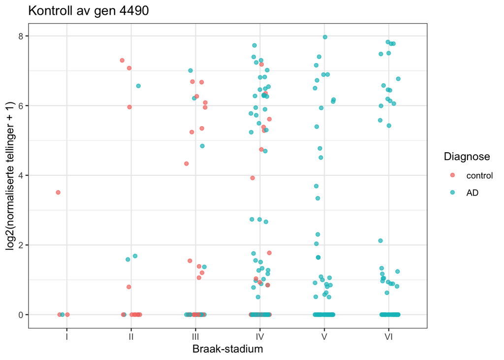

```r
# Hent normaliserte tellinger for genet
gene.check <- data.frame(
  sample = colnames(dds.de),
  expression = as.numeric(
    DESeq2::counts(dds.de, normalized = TRUE)["4490", ]
  ),
  braak = colData(dds.de)$braak,
  diagnosis = colData(dds.de)$diagnosis
)

# Vis uttrykket i hver prøve, gruppert etter Braak
ggplot2::ggplot(
  gene.check,
  ggplot2::aes(
    x = braak,
    y = log2(expression + 1),
    color = diagnosis
  )
) +
  ggplot2::geom_jitter(width = 0.15, height = 0, alpha = 0.7) +
  ggplot2::labs(
    title = "Kontroll av gen 4490",
    x = "Braak-stadium",
    y = "log2(normaliserte tellinger + 1)",
    color = "Diagnose"
  ) +
  ggplot2::theme_bw()
```

```r
# Vis prøvene med høyest uttrykk
head(
  gene.check[order(gene.check$expression, decreasing = TRUE), ],
  10
)
```

```
##         sample expression braak diagnosis
## 115 GSM3577684   249.3287     V        AD
## 203 GSM3577772   225.9236    VI        AD
## 213 GSM3577782   218.5865    VI        AD
## 177 GSM3577746   218.1401    VI        AD
## 124 GSM3577693   211.0803    IV        AD
## 273 GSM3577842   180.8149    VI        AD
## 248 GSM3577817   177.6977    VI        AD
## 155 GSM3577724   168.1252     V        AD
## 62  GSM3577630   167.5961    IV        AD
## 252 GSM3577821   156.6514    IV        AD
```

```r
# Vis hele Braak-resultatet for genet
as.data.frame(res.braak["4490", ])
```

```
##      baseMean log2FoldChange     lfcSE     stat        pvalue       padj
## 4490 23.60888      0.5883954 0.7448359 1114.711 8.713866e-239 1.872e-234
```

```r
# Undersøk prøvenes innflytelse på modellen
cooks.4490 <- assays(dds.de)[["cooks"]]["4490", ]

# Vis de fem høyeste Cook's distance-verdiene
head(sort(cooks.4490, decreasing = TRUE), 5)
```

```
## GSM3577584 GSM3577684 GSM3577772 GSM3577746 GSM3577671
## 0.10034236 0.06396099 0.06145790 0.05599137 0.04907965
```

```r
# Hent informasjon om modelltilpasningen
fit.check <- as.data.frame(S4Vectors::mcols(dds.braak))

# Vis konvergensinformasjon for gen 4490
fit.columns <- grep(
  "Conv",
  colnames(fit.check),
  value = TRUE
)

fit.check["4490", fit.columns, drop = FALSE]
```

```
##      fullBetaConv reducedBetaConv
## 4490         TRUE            TRUE
```

## 4.6 Pathway analysis

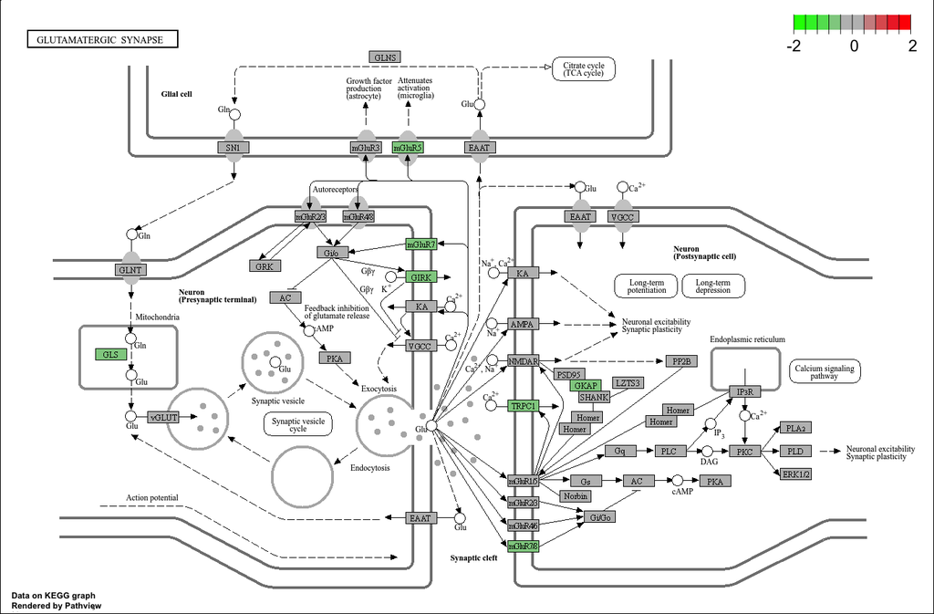

```r
library(pathview)
data("bods", package = "pathview")
data("korg", package = "pathview")

# Hent log2-fold change og bruk Entrez-ID som navn
gene.effects <- res.AD$log2FoldChange
names(gene.effects) <- rownames(res.AD)

# Fjern verdier som mangler eller ikke er endelige
gene.effects <- gene.effects[is.finite(gene.effects)]

# Lag en mappe til figuren
dir.create("figures", showWarnings = FALSE)

# Tegn pathway-kartet
pv.synapse <- pathview::pathview(
  gene.data = gene.effects,
  gene.idtype = "entrez",
  pathway.id = "04724",
  species = "hsa",
  node.sum = "mean",
  limit = list(gene = 2),
  out.suffix = "AD_vs_control",
  kegg.dir = "figures"
)

# Vis figuren i R Markdown
knitr::include_graphics("hsa04724.AD_vs_control.png")
```

## 4.7 Hub genes

```r
# Finn de ti genene som følger hver modul tettest
hub.genes <- do.call(
  rbind,
  lapply(names(module.genes), function(module) {

    genes <- module.genes[[module]]

    # Korrelasjon mellom hvert gen og modulens eigengene
    kME <- as.numeric(cor(
      datExpr[, genes, drop = FALSE],
      MEs[[paste0("ME", module)]],
      use = "pairwise.complete.obs"
    ))

    result <- data.frame(
      Module = module,
      EntrezID = genes,
      kME = kME
    )

    result <- result[order(result$kME, decreasing = TRUE), ]
    head(result, 10)
  })
)

# Legg til vanlige gennavn
hub.genes$Symbol <- unname(
  AnnotationDbi::mapIds(
    org.Hs.eg.db,
    keys = as.character(hub.genes$EntrezID),
    column = "SYMBOL",
    keytype = "ENTREZID",
    multiVals = "first"
  )
)

hub.genes
```

```
##       Module  EntrezID       kME   Symbol
## 535     pink     57475 0.9438504  PLEKHH1
## 757     pink     51114 0.9429441   ZDHHC9
## 214     pink     57556 0.9428122   SEMA6A
## 481     pink      2065 0.9421911    ERBB3
## 438     pink     79899 0.9381504    PRR5L
## 420     pink    118611 0.9378720 C10orf90
## 463     pink     83700 0.9374081     JAM3
## 64      pink      6900 0.9373740    CNTN2
## 594     pink     79905 0.9341533     TMC7
## 754     pink      5354 0.9296501     PLP1
## 798    brown      5575 0.9817796  PRKAR1B
## 280    brown     22924 0.9779390   MAPRE3
## 864    brown     51412 0.9762027   ACTL6B
## 929    brown      9796 0.9760103   PHYHIP
```

[output cut: 26 more lines]

```r
# Hent korrigerte p-verdier fra DESeq2
hub.genes$AD_FDR <- res.AD$padj[
  match(hub.genes$EntrezID, rownames(res.AD))
]

hub.genes$Braak_FDR <- res.braak$padj[
  match(hub.genes$EntrezID, rownames(res.braak))
]

# Marker signifikante sammenhenger
hub.genes$AD_significant <- (
  !is.na(hub.genes$AD_FDR) & hub.genes$AD_FDR < 0.05
)

hub.genes$Braak_significant <- (
  !is.na(hub.genes$Braak_FDR) & hub.genes$Braak_FDR < 0.05
)

hub.genes
```

```
##       Module  EntrezID       kME   Symbol       AD_FDR  Braak_FDR
## 535     pink     57475 0.9438504  PLEKHH1 8.272526e-01 0.06803232
## 757     pink     51114 0.9429441   ZDHHC9 9.083724e-01 0.07163413
## 214     pink     57556 0.9428122   SEMA6A 4.892184e-01 0.14135093
## 481     pink      2065 0.9421911    ERBB3 1.176464e-01 0.03393209
## 438     pink     79899 0.9381504    PRR5L 3.025712e-01 0.06210201
## 420     pink    118611 0.9378720 C10orf90 1.614702e-01 0.03995748
## 463     pink     83700 0.9374081     JAM3 4.936398e-01 0.01821954
## 64      pink      6900 0.9373740    CNTN2 3.044929e-01 0.01430151
## 594     pink     79905 0.9341533     TMC7 7.638693e-01 0.06077146
## 754     pink      5354 0.9296501     PLP1 7.501702e-01 0.05829588
## 798    brown      5575 0.9817796  PRKAR1B 4.398097e-02 0.01545363
## 280    brown     22924 0.9779390   MAPRE3 1.453479e-02 0.02516834
## 864    brown     51412 0.9762027   ACTL6B 4.338920e-02 0.03551810
## 929    brown      9796 0.9760103   PHYHIP 2.387271e-02 0.03579174
```

[output cut: 67 more lines]

# 5 Discussion

# 6 References